# Maps

## TL;DR: Making Effective Maps with `maps` + `ggplot2`

- **Get map data** with `ggplot2::map_data()` (backed by `{maps}`): e.g., `"world"`, `"world2"`, `"usa"`, `"state"`, `"county"`. It returns a tidy data frame of polygon points.
- **Always map groups**: Use `aes(group = group)` so polygon edges connect correctly; otherwise you get spaghetti lines.
- **Control aspect ratio** with `coord_fixed()` so geography isn’t distorted by figure size.
- **Tame clutter**: Hide grid/axes via `theme(...)` and selectively disable legends with `guides(fill = "none")` when a categorical legend isn’t useful.
- **Choropleths**: Map values to `fill=`, pick perceptually sensible palettes, and (critically) keep **consistent bins/legends** across facets or time points.
- **Joins for data**: Align key names (lowercase, remove spaces) before a `left_join()` with map polygons (e.g., `subregion` vs. `county`).
- **Ethics & integrity**: Avoid misleading color scales or changing breakpoints over time. Prefer consistent bins, clear titles, and notes on data sources.

Plots of maps can be very powerful, very informative and very aesthetically pleasing visualizations. However, they can also be misleading if not created correctly. Here we will introduce one R package for creating effective and informative maps and show how to correct a misleading set of maps.

There are several R packages available that can be used to create plots of maps. We will be focusing on one of the packages, `maps`, because of how intuitive it is, the data available, and because it works well with `ggplot2`. We will see several of the options available with this package, but you can read more about the `maps` package [here](https://cran.r-project.org/web/packages/maps/maps.pdf) and see more examples [here](https://eriqande.github.io/rep-res-web/lectures/making-maps-with-R.html). Other available R packages include `usmap`, `ggmap`, `ggspatial`, `sf`, `urbnmapr` and `rnaturalearth`, and we recommend exploring the examples (like [this one](https://ggplot2-book.org/maps.html)) and documentation for these packages for additional types of map plots.

## World Map

The `maps` package contains a lot of outlines of continents, countries, states, and counties. In order to map these using `ggplot2`, we must specify which type of map we want with `map_data()`. ggplot2 provides the `map_data()` as a function that turns a series of points along an outline (from the `maps` package) into a data frame of those points. Below we will see maps of the world, a few countries, the entire US, US states and US counties, but there are more options available with this package.

We can save map data as a data frame to see what data is available and then map with `ggplot`. Let’s look at the “world” option.

```r
# Pull out world map data frame
world_map <- map_data("world")
dim(world_map)
```

```
## [1] 99338     6
```

```r
head(world_map)
```

```
##        long      lat group order region subregion
## 1 -69.89912 12.45200     1     1  Aruba      <NA>
## 2 -69.89571 12.42300     1     2  Aruba      <NA>
## 3 -69.94219 12.43853     1     3  Aruba      <NA>
## 4 -70.00415 12.50049     1     4  Aruba      <NA>
## 5 -70.06612 12.54697     1     5  Aruba      <NA>
## 6 -70.05088 12.59707     1     6  Aruba      <NA>
```

We can see the latitude (`lat`) and longitude (`long`) for different regions of the world are available. Here, `region` corresponds to a country and `subregion` indicates additional information about that country if available. For example, the Virgin Islands fall into different political jurisdictions, so you’ll see “British” and “US” under `subregion` for the Virgin Islands.

The column `order` shows in which order ggplot should “connect the dots” when plotting. `group` is important since functions in `ggplot2` can take a group argument which controls (amongst other things) whether adjacent points should be connected by lines. If they are in the same group, then they get connected, but if they are in different groups then they don’t. Essentially, having two points in different groups means that ggplot “lifts the pen” when going between them. As we’ll see below, including `group = group` in the `aes()` argument will plot the outlines of countries. If we don’t include `group = group`, the plot will have many lines connecting different parts of different countries and will be impossible to interpret.

For this plot we also use `fill` (to denote the color to fill the countries with) and `color` (the outline color for each country). We will see more options as we create more complex maps.

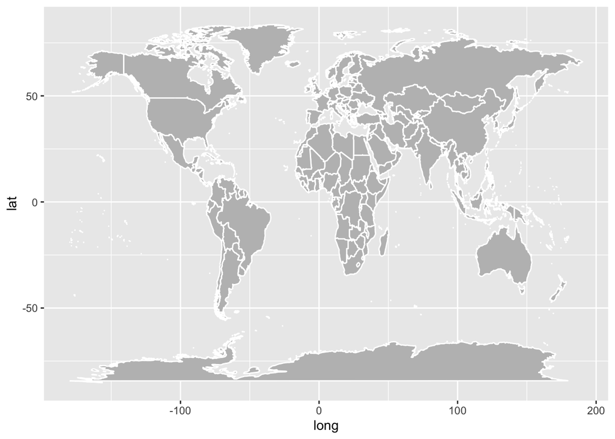

```r
# Basic example of a world map
world_map %>% ggplot(aes(x = long, y = lat, group = group)) +
              geom_polygon(fill = "gray", color = "white")
```

We can also map one specific country, or a few countries. If plotting one country, the second argument of `map_data` should include the name of the country. Note that the name of the country can be typed using all lowercase or with the first letter capitalized. We also introduce `coord_fixed` to make plots even better looking. This fixes the relationship between one unit in the y direction and one unit in the x direction. Then, even if you change the outer dimensions of the plot (i.e. by changing the window size or the size of the pdf file you are saving it to for example), the aspect ratio remains unchanged.

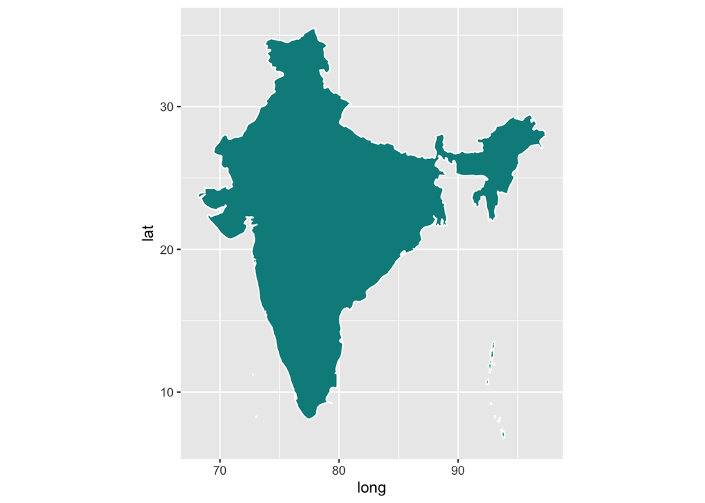

```r
india_map <- map_data("world", "India")

india_map %>% ggplot(aes(x = long, y = lat, group = group)) +
              geom_polygon(fill = "cyan4", color = "white") +
              coord_fixed(1.2)
```

If we want to plot more than one country, we need to supply a string of country names as the second argument. Here we introduce `theme_set(theme_bw())`. As we’ve seen before, the default background color for `ggplot2` is a light gray with white grid lines. If you would prefer a different color background you can use different themes. `theme_set(theme_bw())` makes the background color white and the grid lines light gray. This just has to do with preference.

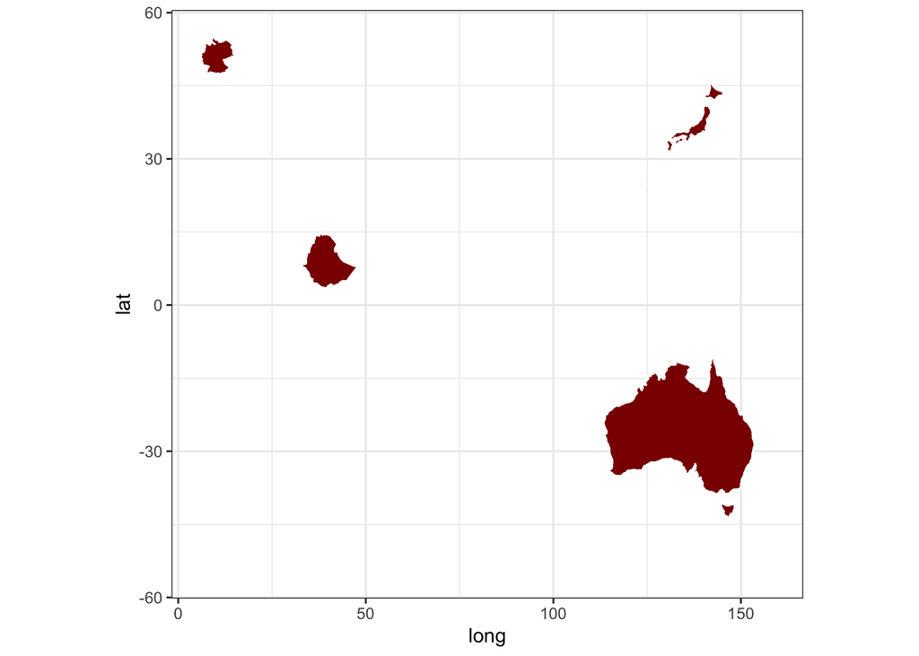

```r
theme_set(theme_bw())
multiple_countries_map <- map_data("world", c("Japan", "Ethiopia", "Australia", "Germany"))
multiple_countries_map %>% ggplot(aes(x = long, y = lat, group = group)) +
                           geom_polygon(fill = "darkred", color = "white") +
                           coord_fixed(1.3)
```

If you want to remove the longitude and latitude axes as well as the grid lines, you can use the `theme` layer and add the following code to the plot. Since we set a theme for all plots above using `theme_set(theme_bw())`, we need to reset the background to the ggplot default using `theme_set(theme_grey())` first.

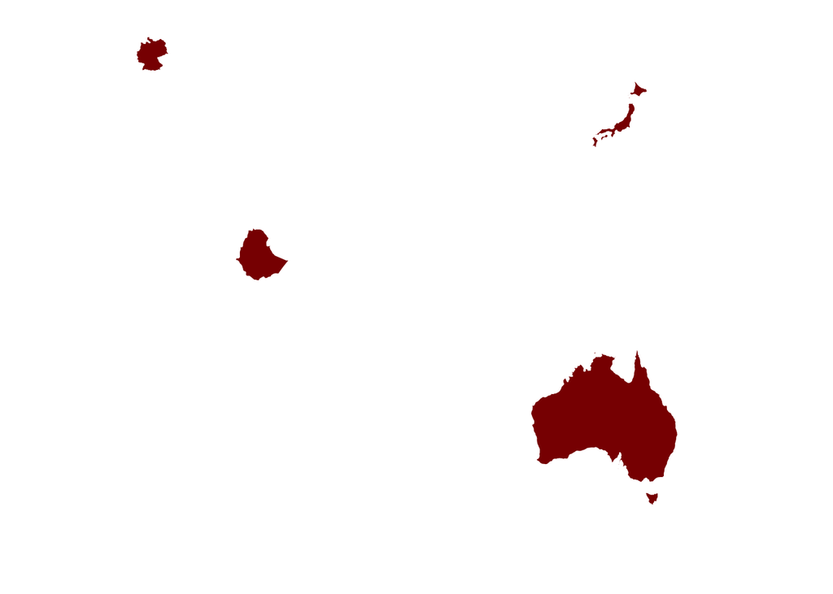

```r
theme_set(theme_grey()) # back to the default background
multiple_countries_map %>% ggplot(aes(x = long, y = lat, group = group)) +
                           geom_polygon(fill = "darkred", color = "white") +
                           theme(panel.grid.major = element_blank(),
                                 panel.background = element_blank(),
                                 axis.title = element_blank(),
                                 axis.text = element_blank(),
                                 axis.ticks = element_blank()) +
                           coord_fixed(1.3)
```

We can also add `fill = region` to the `aes()` function to fill each country with a different color and add a legend.

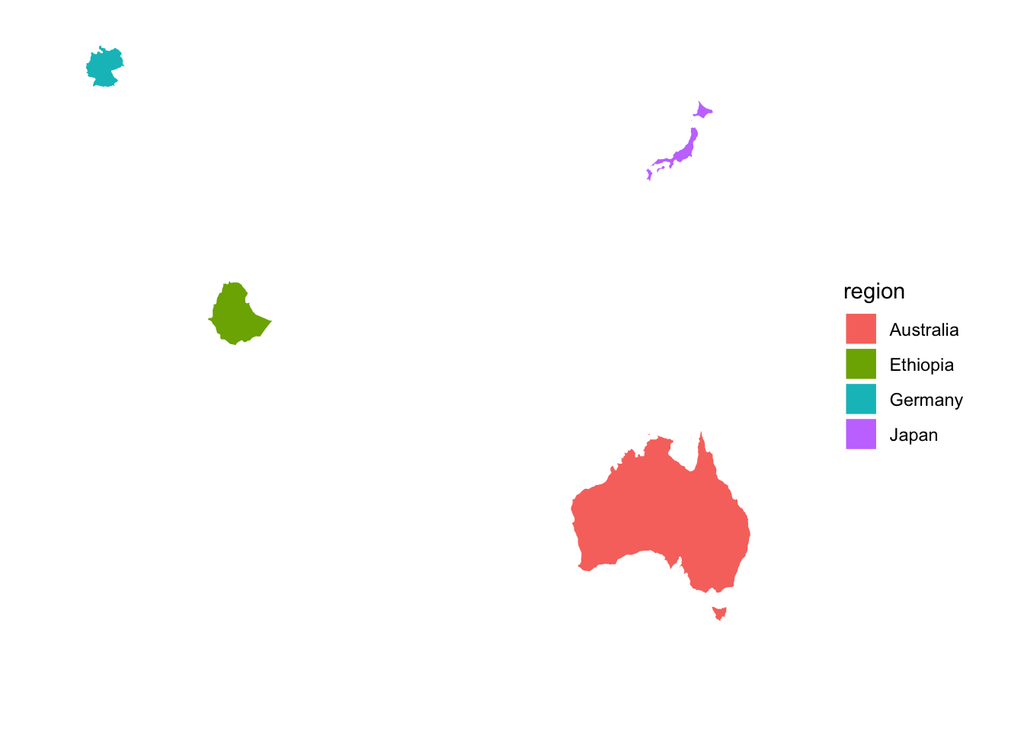

```r
theme_set(theme_grey()) # back to the default background
multiple_countries_map %>% ggplot(aes(x = long, y = lat, group = group, fill = region)) +
                           geom_polygon(color = "white") +
                           theme(panel.grid.major = element_blank(),
                                 panel.background = element_blank(),
                                 axis.title = element_blank(),
                                 axis.text = element_blank(),
                                 axis.ticks = element_blank()) +
                           coord_fixed(1.3)
```

## US Map

There are multiple ways of plotting the US with the `maps` package. You could use the `world` data and specify `usa` as the country:

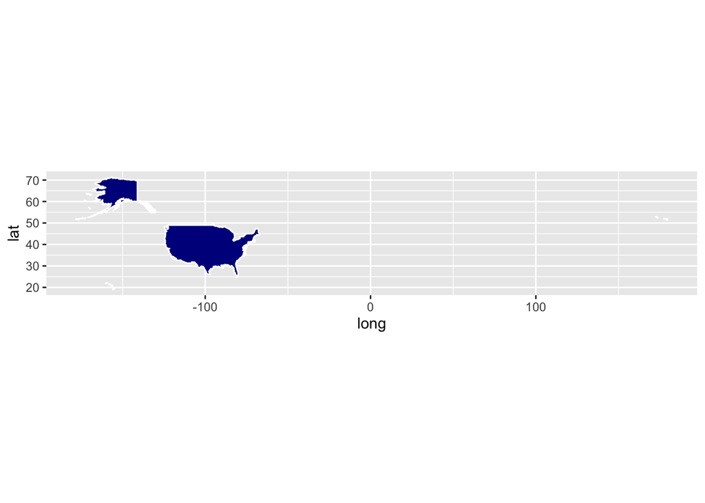

```r
us_map <- map_data("world", "usa")
us_map %>% ggplot(aes(x = long, y = lat, group = group)) +
           geom_polygon(fill = "blue4", color = "white") +
           coord_fixed(1.3)
```

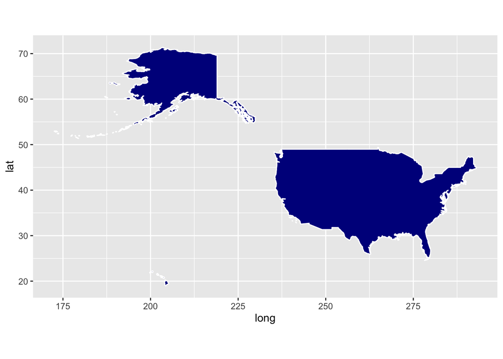

```r
better_us_map <- map_data("world2", "USA")
better_us_map %>% ggplot(aes(x = long, y = lat, group = group)) +
                  geom_polygon(fill = "blue4", color = "white") +
                  coord_fixed(1.3)
```

`world2` centers the plot on the Pacific Ocean, allowing us to see Hawaii and bigger versions of Alaska and the mainland states (also known as the lower 48 or contiguous 48).

If you don’t need to plot Alaska and Hawaii, an even better option is to not use `world` or `world2` and instead use `usa`; the `maps` package provides data specifically for the mainland states of the US. If we use `usa` instead, we get a much better plot of the US (without Alaska and Hawaii).

We can also experiment with color a bit and have the outline color set to purple and the fill color set to `NA`, which leaves it blank or transparent to the background color.

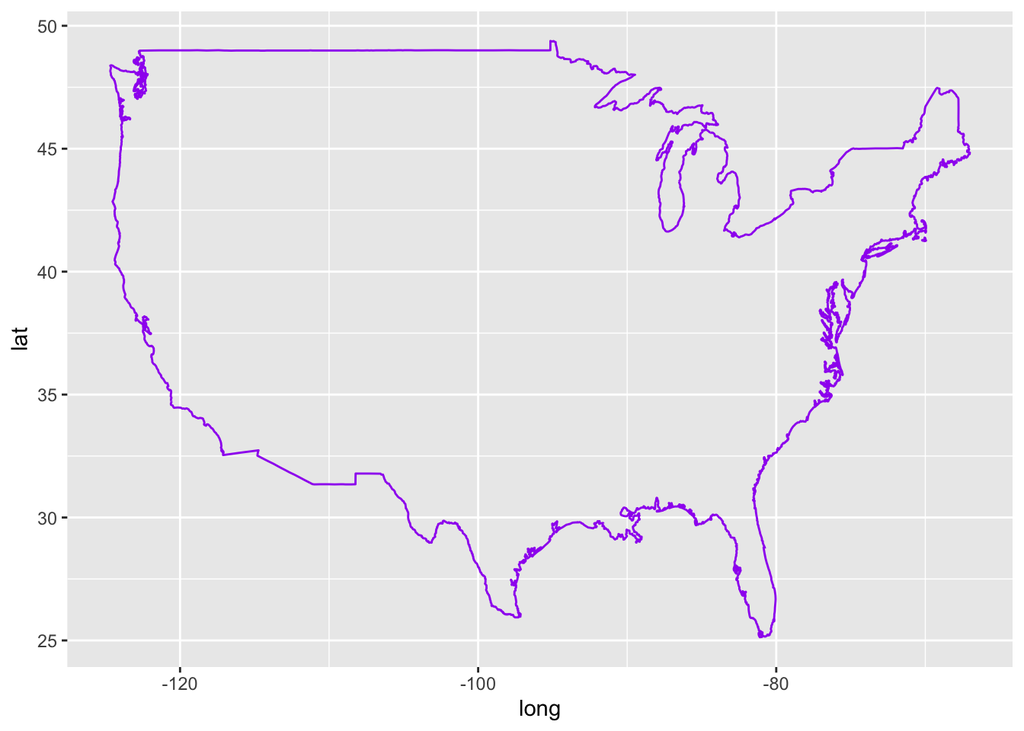

```r
usa <- map_data("usa")
usa %>% ggplot(aes(x = long, y = lat, group = group)) +
        geom_polygon(color = "purple", fill = NA)
```

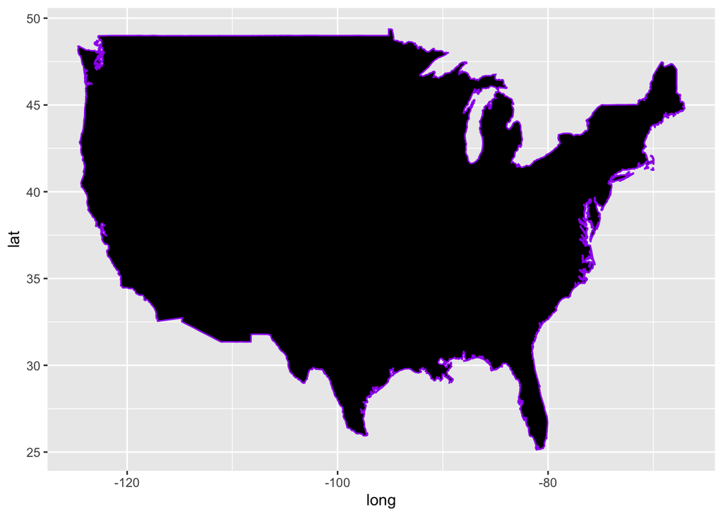

```r
usa %>% ggplot(aes(x = long, y = lat, group = group)) +
        geom_polygon(color = "purple", fill = "black")
```

## US States

If we want to show individual states, we should instead use the `state` option. But we see a problem - a massive legend is made with one color per state. This is a problem because it eats up most of the plot area. We could make the plot bigger to accommodate the legend, but it would still be difficult for someone without much knowledge of the states to figure out which color corresponds to which state. A better option would be to remove the legend and add labels to the states themselves.

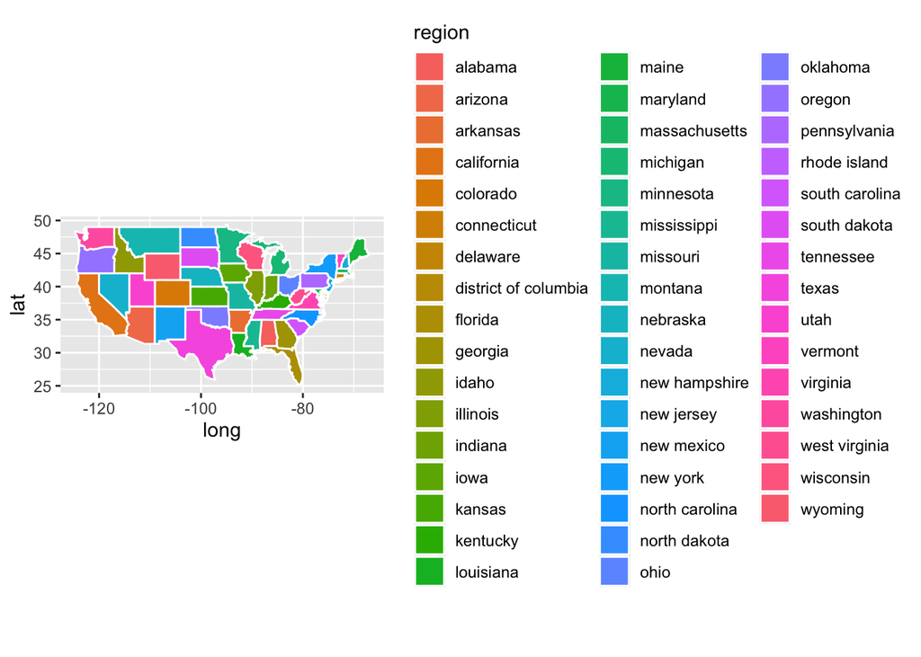

```r
us_states <- map_data("state")

us_states %>% ggplot(aes(x = long, y = lat, fill = region, group = group)) +
              geom_polygon(color = "white") +
              coord_fixed(1.3)
```

To remove the legend we add the layer `guides(fill = FALSE)`.

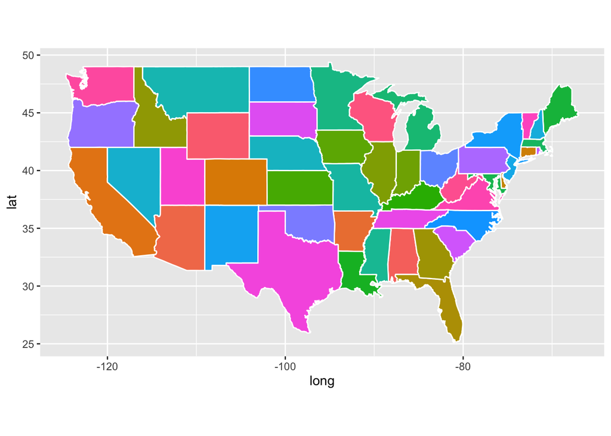

```r
us_states %>% ggplot(aes(x = long, y = lat, fill = region, group = group)) +
              geom_polygon(color = "white") +
              coord_fixed(1.3) +
              guides(fill = FALSE) # do this to leave off the color legend
```

Adding state labels with the `maps` package is more complex and not worth our time here. If you need to label states, we recommend using the `usmap` package and first reading [this](https://cran.r-project.org/web/packages/usmap/vignettes/mapping.html) post and then [this](https://cran.r-project.org/web/packages/usmap/vignettes/advanced-mapping.html) post.

## US Counties

Mapping US state counties is also possible using the `maps` package by using `map_data("county")`. Here we choose a red outline and no fill color, but we notice that the county lines are a little thick and make some counties difficult to see.

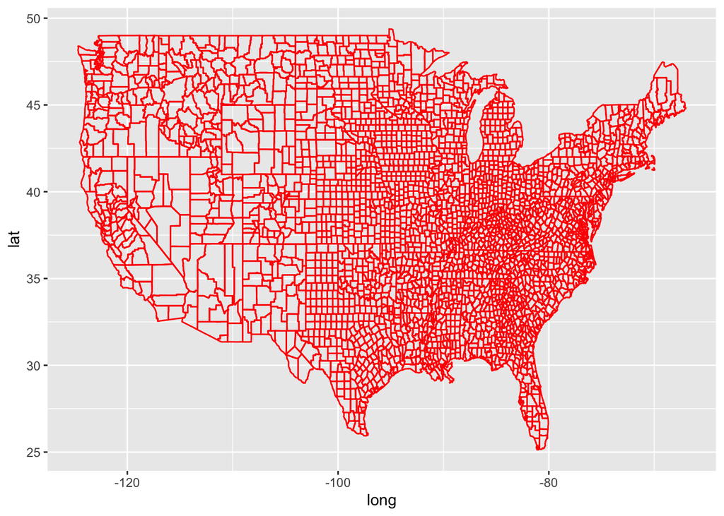

```r
AllCounty <- map_data("county")
AllCounty %>% ggplot(aes(x = long, y = lat, group = group)) +
              geom_polygon(color = "red", fill = NA)
```

We can change the width of the lines using the `size` argument, making individual counties a bit easier to see.

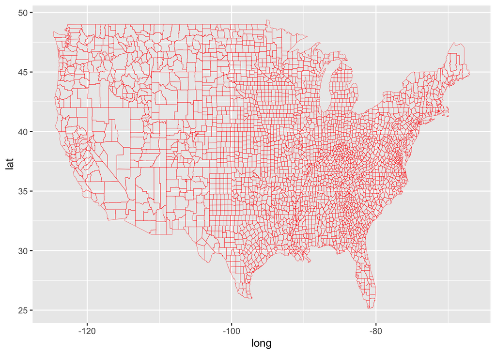

```r
AllCounty %>% ggplot(aes(x = long, y = lat, group = group)) +
              geom_polygon(color = "red", fill = NA, size = .1 )
```

## Mapping US murder rates

Let’s now create a choropleth map showing the murder rate per 100,000 residents in each U.S. state using our `murders` dataset.

We begin by loading the necessary packages. The `dslabs` package provides the `murders` dataset, and the `maps` package provides the polygon coordinates needed to draw the boundaries of U.S. states. We also load `tidyverse` for data wrangling and plotting, and `RColorBrewer` for a red color palette that we will use to represent the murder rate.

```r
library(tidyverse)
library(maps)
library(dslabs)
library(RColorBrewer)

data(murders)
murders <- murders %>% mutate(rate = total / population * 100000)
states_map <- map_data("state")

head(murders)
```

```
##        state abb region population total     rate
## 1    Alabama  AL  South    4779736   135 2.824424
## 2     Alaska  AK   West     710231    19 2.675186
## 3    Arizona  AZ   West    6392017   232 3.629527
## 4   Arkansas  AR  South    2915918    93 3.189390
## 5 California  CA   West   37253956  1257 3.374138
## 6   Colorado  CO   West    5029196    65 1.292453
```

```r
head(states_map)
```

```
##        long      lat group order  region subregion
## 1 -87.46201 30.38968     1     1 alabama      <NA>
## 2 -87.48493 30.37249     1     2 alabama      <NA>
## 3 -87.52503 30.37249     1     3 alabama      <NA>
## 4 -87.53076 30.33239     1     4 alabama      <NA>
## 5 -87.57087 30.32665     1     5 alabama      <NA>
## 6 -87.58806 30.32665     1     6 alabama      <NA>
```

Before we can merge these datasets, we need to ensure the state names match. The map data uses lowercase state names in a column called `region`, so we create a new `region` column in the `murders` dataset that matches this format. We then use `left_join()` to merge the two datasets based on this shared column.

```r
murders <- murders %>% mutate(region = tolower(state))
head(murders)
```

```
##        state abb     region population total     rate
## 1    Alabama  AL    alabama    4779736   135 2.824424
## 2     Alaska  AK     alaska     710231    19 2.675186
## 3    Arizona  AZ    arizona    6392017   232 3.629527
## 4   Arkansas  AR   arkansas    2915918    93 3.189390
## 5 California  CA california   37253956  1257 3.374138
## 6   Colorado  CO   colorado    5029196    65 1.292453
```

```r
merged_data <- left_join(states_map, murders, by = "region")
head(merged_data)
```

```
##        long      lat group order  region subregion   state abb population total
## 1 -87.46201 30.38968     1     1 alabama      <NA> Alabama  AL    4779736   135
## 2 -87.48493 30.37249     1     2 alabama      <NA> Alabama  AL    4779736   135
## 3 -87.52503 30.37249     1     3 alabama      <NA> Alabama  AL    4779736   135
## 4 -87.53076 30.33239     1     4 alabama      <NA> Alabama  AL    4779736   135
## 5 -87.57087 30.32665     1     5 alabama      <NA> Alabama  AL    4779736   135
## 6 -87.58806 30.32665     1     6 alabama      <NA> Alabama  AL    4779736   135
##       rate
## 1 2.824424
## 2 2.824424
## 3 2.824424
## 4 2.824424
## 5 2.824424
## 6 2.824424
```

Now we can create the map. We use `ggplot2` with `geom_polygon()` to draw each state, using the calculated murder rate to determine the fill color. We apply a red gradient to represent higher rates, remove the axes and background for a clean look using `theme_void()`, and fix the map’s aspect ratio with `coord_fixed()`.

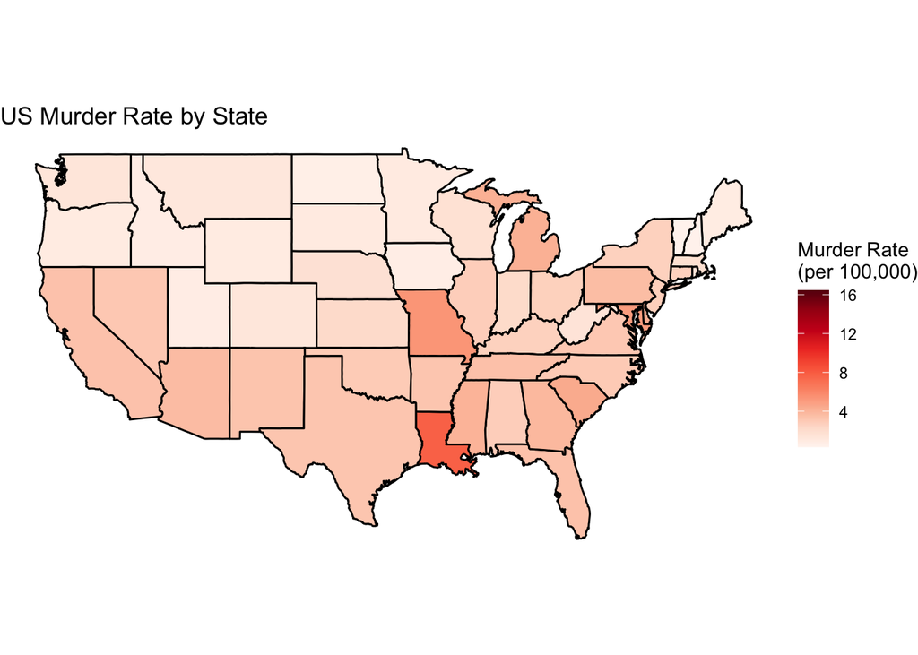

```r
merged_data %>%
ggplot(aes(long, lat, group = group, fill = rate)) +
  geom_polygon(color = "black") +
  scale_fill_gradientn(colors = brewer.pal(9, "Reds")) +
  theme_void() +
  labs(title = "US Murder Rate by State",
       fill = "Murder Rate \n(per 100,000)") +
  coord_fixed(1.3)
```

To enhance readability, we add state abbreviations to the map. We use state center coordinates from the base R `state.center` data, along with abbreviations from `state.abb`. These are plotted using `annotate()` to add text directly to the map. We exclude Alaska and Hawaii for better visual balance.

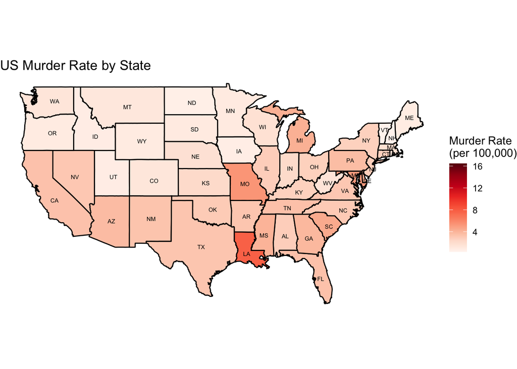

```r
library(ggrepel)
centroids <- data.frame(region = tolower(state.name),
                        long = state.center$x,
                        lat = state.center$y)

centroids$abb <- state.abb[match(centroids$region,
                                 tolower(state.name))]

centroids <- centroids %>%
  filter(!region %in% c("alaska", "hawaii"))

merged_data %>%
ggplot(aes(long, lat, group = group, fill = rate)) +
  geom_polygon(color = "black") +
  scale_fill_gradientn(colors = brewer.pal(9, "Reds")) +
  theme_void() +
  labs(title = "US Murder Rate by State",
       fill = "Murder Rate \n(per 100,000)") +
  coord_fixed(1.3) +
  with(centroids,
       annotate(geom = "text", x = long, y = lat, label = abb,
                size = 2, color = "black", family = "Arial"))
```

## Mapping Global Life Expectancy

Now let’s visualize life expectancy across countries in 2015 using a world map. We use the `gapminder` dataset from `dslabs`, filtered to the year 2015. The map data is retrieved from `map_data("world")`. We join this to the `gapminder` data using country names.

```r
library(plyr)
library(tidyverse)
library(maps)
library(dslabs)

data(gapminder)
gapminder_2015 <- gapminder %>%
  filter(year == 2015)

world_map <- map_data("world")
merged_world <- left_join(world_map, gapminder_2015,
                          by = c("region" = "country"))

head(merged_world)
```

```
##        long      lat group order region subregion year infant_mortality
## 1 -69.89912 12.45200     1     1  Aruba      <NA> 2015               NA
## 2 -69.89571 12.42300     1     2  Aruba      <NA> 2015               NA
## 3 -69.94219 12.43853     1     3  Aruba      <NA> 2015               NA
## 4 -70.00415 12.50049     1     4  Aruba      <NA> 2015               NA
## 5 -70.06612 12.54697     1     5  Aruba      <NA> 2015               NA
## 6 -70.05088 12.59707     1     6  Aruba      <NA> 2015               NA
##   life_expectancy fertility population gdp continent  region.y
## 1           75.72      1.66     103889  NA  Americas Caribbean
## 2           75.72      1.66     103889  NA  Americas Caribbean
## 3           75.72      1.66     103889  NA  Americas Caribbean
## 4           75.72      1.66     103889  NA  Americas Caribbean
## 5           75.72      1.66     103889  NA  Americas Caribbean
## 6           75.72      1.66     103889  NA  Americas Caribbean
```

We map life expectancy values using a continuous color scale (`viridis` palette) and `geom_polygon()` to draw countries.

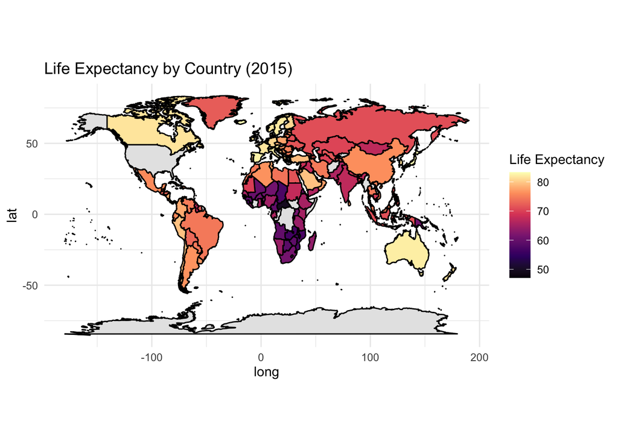

```r
ggplot(merged_world, aes(long, lat, group = group,
                         fill = life_expectancy)) +
  geom_polygon(color = "black") +
  scale_fill_viridis_c(option = "magma",
                       na.value = "gray90") +
  theme_minimal() +
  labs(title = "Life Expectancy by Country (2015)",
       fill = "Life Expectancy") +
  coord_fixed(1.3)
```

We can see that there is missing data where we should have data. For example, the rate for the US does not show on the plot. To identify countries in the world map that didn’t match with `gapminder_2015`, we use `anti_join()`. This helps detect mismatches due to inconsistent naming.

```r
issues <- anti_join(world_map, gapminder_2015, by = c("region" = "country"))
levels(as.factor(issues$region))
```

```
##  [1] "Afghanistan"                         "American Samoa"
##  [3] "Andorra"                             "Anguilla"
##  [5] "Antarctica"                          "Antigua"
##  [7] "Ascension Island"                    "Azores"
##  [9] "Barbuda"                             "Bermuda"
## [11] "Bonaire"                             "Canary Islands"
## [13] "Cayman Islands"                      "Chagos Archipelago"
## [15] "Christmas Island"                    "Cocos Islands"
## [17] "Cook Islands"                        "Curacao"
## [19] "Democratic Republic of the Congo"    "Dominica"
## [21] "Falkland Islands"                    "Faroe Islands"
## [23] "French Guiana"                       "French Southern and Antarctic Lands"
## [25] "Grenadines"                          "Guadeloupe"
## [27] "Guam"                                "Guernsey"
## [29] "Heard Island"                        "Isle of Man"
```

[output cut: 27 more lines]

```r
levels(gapminder_2015$country)
```

```
##   [1] "Albania"                        "Algeria"
##   [3] "Angola"                         "Antigua and Barbuda"
##   [5] "Argentina"                      "Armenia"
##   [7] "Aruba"                          "Australia"
##   [9] "Austria"                        "Azerbaijan"
##  [11] "Bahamas"                        "Bahrain"
##  [13] "Bangladesh"                     "Barbados"
##  [15] "Belarus"                        "Belgium"
##  [17] "Belize"                         "Benin"
##  [19] "Bhutan"                         "Bolivia"
##  [21] "Bosnia and Herzegovina"         "Botswana"
##  [23] "Brazil"                         "Brunei"
##  [25] "Bulgaria"                       "Burkina Faso"
##  [27] "Burundi"                        "Cambodia"
##  [29] "Cameroon"                       "Canada"
```

[output cut: 78 more lines]

We then examine and revise the country names in the `gapminder` data to match those used in the map data using `revalue()`.

We then replot the map to reflect the updated joins. It’s not possible to reconcile all mismatched countries, but we can fix the following and plot again.

```r
gapminder_2015 <- gapminder %>% filter(year == 2015) %>%
  mutate(country =
           revalue(country, c("Antigua and Barbuda" = "Antigua",
                              "Samoa" = "American Samoa",
                              "Congo, Rep." = "Republic of Congo",
                              "Congo, Dem. Rep." = "Democratic Republic of the Congo",
                              "Kyrgyz Republic" = "Kyrgyzstan",
                              "St. Lucia" = "Saint Lucia",
                              "St. Vincent and the Grenadines" = "Saint Vincent",
                              "Trinidad and Tobago" = "Trinidad",
                              "United Kingdom" = "UK",
                              "United States" = "USA")))

world_map <- map_data("world")
merged_world <- left_join(world_map, gapminder_2015, by = c("region" = "country"))
```

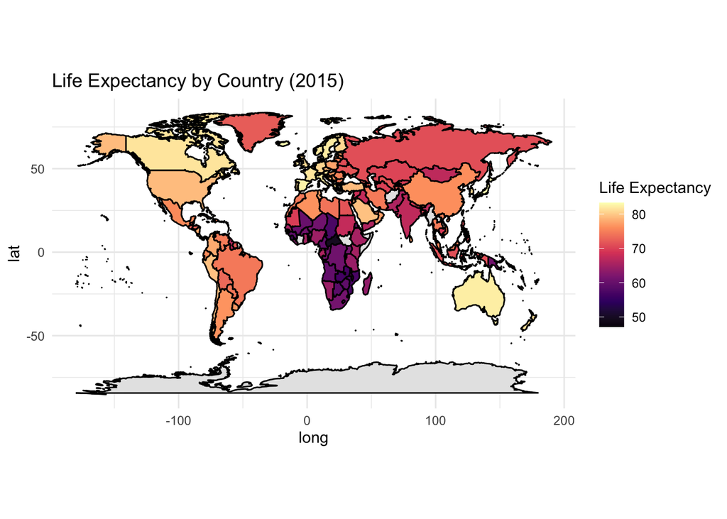

```r
ggplot(merged_world, aes(long, lat, group = group, fill = life_expectancy)) +
  geom_polygon(color = "black") +
  scale_fill_viridis_c(option = "magma", na.value = "gray90") +
  theme_minimal() +
  labs(title = "Life Expectancy by Country (2015)", fill = "Life Expectancy") +
  coord_fixed(1.3)
```

## Case Study: Georgia Counties COVID-19 Cases

Now that we know the basic setup for plotting different kinds of maps, let’s create a meaningful map. Specifically, let’s create a corrected version of a misleading set of maps.

On July 17th, 2020 [Andisheh Nouraee](https://twitter.com/andishehnouraee) tweeted about the following screenshots on Twitter, calling out Georgia’s Department of Public Health for hiding the severity of the COVID-19 outbreak in Georgia with its map visualizations.

[figure not shown]

Nouraee had been taking daily screenshots and noticed that the legend numbers kept changing. With changing legend number cutoffs for each color, it seems like the number of cases is staying steady, rather than increasing. As ethical data scientists and members of the Harvard Chan School Community, we know that plots like this spread misinformation and can lead to worse health outcomes. In order to correct this mistake and accurately show the severity of the outbreak, we will be recreating this plot with a common legend for both dates. We’ll use the `maps` package and a bit of data wrangling to achieve the desired final product.

Let’s first make a plot of Georgia and its counties. We specify the `county` data as before, but add `georgia` to indicate we only want the counties for the state of Georgia to be plotted.

```r
GeorgiaCounty <- map_data("county", "georgia")
head(GeorgiaCounty)
```

```
##        long      lat group order  region subregion
## 1 -82.44862 31.94813     1     1 georgia   appling
## 2 -82.42570 31.94813     1     2 georgia   appling
## 3 -82.40852 31.94240     1     3 georgia   appling
## 4 -82.39706 31.94240     1     4 georgia   appling
## 5 -82.38560 31.93094     1     5 georgia   appling
## 6 -82.35122 31.91948     1     6 georgia   appling
```

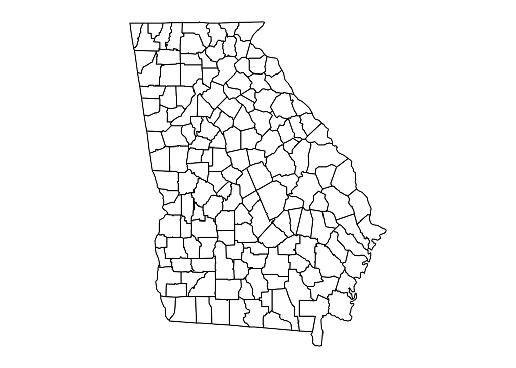

```r
GeorgiaCounty %>% ggplot(aes(x = long, y = lat, group = group)) +
                  geom_polygon(fill = "white", color = "black") +
                  theme(panel.grid.major = element_blank(),
                        panel.background = element_blank(),
                        axis.title = element_blank(),
                        axis.text = element_blank(),
                        axis.ticks = element_blank()) +
                  coord_fixed(1.3)
```

```r
url <- "https://raw.githubusercontent.com/nytimes/covid-19-data/master/us-counties.csv"
cases <- read_csv(url)
head(cases)
```

```
## # A tibble: 6 × 6
##   date       county    state      fips  cases deaths
##   <date>     <chr>     <chr>      <chr> <dbl>  <dbl>
## 1 2020-01-21 Snohomish Washington 53061     1      0
## 2 2020-01-22 Snohomish Washington 53061     1      0
## 3 2020-01-23 Snohomish Washington 53061     1      0
## 4 2020-01-24 Cook      Illinois   17031     1      0
## 5 2020-01-24 Snohomish Washington 53061     1      0
## 6 2020-01-25 Orange    California 06059     1      0
```

We can see we have more data than we need since we are focusing on Georgia and only two specific dates. Let’s filter out rows we won’t need for this plot and save the relevant rows as a new data frame.

```r
dates <- c(ymd("2020-07-02", "2020-07-17"))
georgia_cases <- cases %>% filter(state == "Georgia", date %in% dates)

dim(georgia_cases)
```

```
## [1] 320   6
```

```r
head(georgia_cases)
```

```
## # A tibble: 6 × 6
##   date       county   state   fips  cases deaths
##   <date>     <chr>    <chr>   <chr> <dbl>  <dbl>
## 1 2020-07-02 Appling  Georgia 13001   266     14
## 2 2020-07-02 Atkinson Georgia 13003   155      2
## 3 2020-07-02 Bacon    Georgia 13005   254      4
## 4 2020-07-02 Baker    Georgia 13007    43      3
## 5 2020-07-02 Baldwin  Georgia 13009   543     34
## 6 2020-07-02 Banks    Georgia 13011   140      1
```

Looking back at the original plots, we find that the number of cases are presented per 100,000 people. We need to know the population of each county in Georgia before we can create a case rate per 100,000 people. But we aren’t provided population counts in the `georgia_cases` or `GeorgiaCounty` data frames - we need to find another dataset to pull this information from and join it with what we have.

We can get the population data we need from the [Georgia Department of Public Health website](https://dph.georgia.gov/covid-19-daily-status-report). There isn’t a raw version of this dataset available so we downloaded it, saved it as `county_pop.csv`, and placed it in our course data visualization folder on GitHub.

Now we can read in the data and see what we have.

```r
pop_data <- read_csv("county_pop.csv")
dim(pop_data)
```

```
## [1] 161  12
```

```r
head(pop_data)
```

```
## # A tibble: 6 × 12
##   county_name cases county_id `State FIPS code` `County FIPS code` population
##   <chr>       <dbl> <chr>     <chr>             <chr>                   <dbl>
## 1 Appling      1054 US-13001  13                1                       18561
## 2 Atkinson      447 US-13003  13                3                        8330
## 3 Bacon         602 US-13005  13                5                       11404
## 4 Baker          84 US-13007  13                7                        3116
## 5 Baldwin      2132 US-13009  13                9                       44428
## 6 Banks         501 US-13011  13                11                      19982
## # ℹ 6 more variables: hospitalization <dbl>, deaths <dbl>, `case rate` <dbl>,
## #   `death rate` <dbl>, `14 day case rate` <dbl>, `14 day cases` <dbl>
```

The state counties are listed under `county_name` and population under `population`. These are the only 2 columns we need for joining population data to our cases data frame. First we only keep the `county_name` and `population` columns to make the join simpler and to make sure we don’t create any duplicate columns when joining to the cases data frame. Next we use `left_join` to add the population for each county to the cases data frame. Note that the column names for county are different in each dataset - in the cases data frame the column name is `county` while it is `county_name` in the population data frame. We could rename `county_name` to `county`, or we can simply let the join function know that the data frames have different names for the same thing using `by = c("county" = "county_name")`.

```r
pop_data <- pop_data %>%
  dplyr::select(county_name, population)

data_full <- left_join(georgia_cases, pop_data, by = c("county" = "county_name"))
dim(data_full)
```

```
## [1] 320   7
```

```r
head(data_full)
```

```
## # A tibble: 6 × 7
##   date       county   state   fips  cases deaths population
##   <date>     <chr>    <chr>   <chr> <dbl>  <dbl>      <dbl>
## 1 2020-07-02 Appling  Georgia 13001   266     14      18561
## 2 2020-07-02 Atkinson Georgia 13003   155      2       8330
## 3 2020-07-02 Bacon    Georgia 13005   254      4      11404
## 4 2020-07-02 Baker    Georgia 13007    43      3       3116
## 5 2020-07-02 Baldwin  Georgia 13009   543     34      44428
## 6 2020-07-02 Banks    Georgia 13011   140      1      19982
```

Now that the `population` column has been added to the `cases` data frame and a new combined data frame, `data_full`, has been created, we can create a cases per 100,000 population variable called `rate`.

```r
data_full <- data_full %>%
  mutate(rate = 100000*(cases/population))
head(data_full)
```

```
## # A tibble: 6 × 8
##   date       county   state   fips  cases deaths population  rate
##   <date>     <chr>    <chr>   <chr> <dbl>  <dbl>      <dbl> <dbl>
## 1 2020-07-02 Appling  Georgia 13001   266     14      18561 1433.
## 2 2020-07-02 Atkinson Georgia 13003   155      2       8330 1861.
## 3 2020-07-02 Bacon    Georgia 13005   254      4      11404 2227.
## 4 2020-07-02 Baker    Georgia 13007    43      3       3116 1380.
## 5 2020-07-02 Baldwin  Georgia 13009   543     34      44428 1222.
## 6 2020-07-02 Banks    Georgia 13011   140      1      19982  701.
```

We have one more join to do before we can create the plot. The `data_full` data frame needs to be joined to the `GeorgiaCounty` data frame we created earlier that contains the mapping data for the counties. Before we can join, look at the `county` column in `data_full` and `subregion` column in `GeorgiaCounty`. These are both referring to the counties in Georgia, but the `county` entries are capitalized while `subregion` entries are not. If we want to join these data frames, the quickest way will be to make the `county` column entries lowercase using `str_to_lower` and then joining.

```r
georgia_map <- data_full %>%
  mutate(county = str_to_lower(county)) %>%
  left_join(GeorgiaCounty, by = c("county" = "subregion"))

dim(georgia_map)
```

```
## [1] 10192    13
```

```r
head(georgia_map)
```

```
## # A tibble: 6 × 13
##   date       county  state fips  cases deaths population  rate  long   lat group
##   <date>     <chr>   <chr> <chr> <dbl>  <dbl>      <dbl> <dbl> <dbl> <dbl> <dbl>
## 1 2020-07-02 appling Geor… 13001   266     14      18561 1433. -82.4  31.9     1
## 2 2020-07-02 appling Geor… 13001   266     14      18561 1433. -82.4  31.9     1
## 3 2020-07-02 appling Geor… 13001   266     14      18561 1433. -82.4  31.9     1
## 4 2020-07-02 appling Geor… 13001   266     14      18561 1433. -82.4  31.9     1
## 5 2020-07-02 appling Geor… 13001   266     14      18561 1433. -82.4  31.9     1
## 6 2020-07-02 appling Geor… 13001   266     14      18561 1433. -82.4  31.9     1
## # ℹ 2 more variables: order <int>, region <chr>
```

Now we are ready to start plotting. Before we specify the cutoffs and colors we want, let’s create the default version of the plot with counties filled by case rate and a subplot for each date. Note that we need to remove the `fill = "white"` code we used earlier.

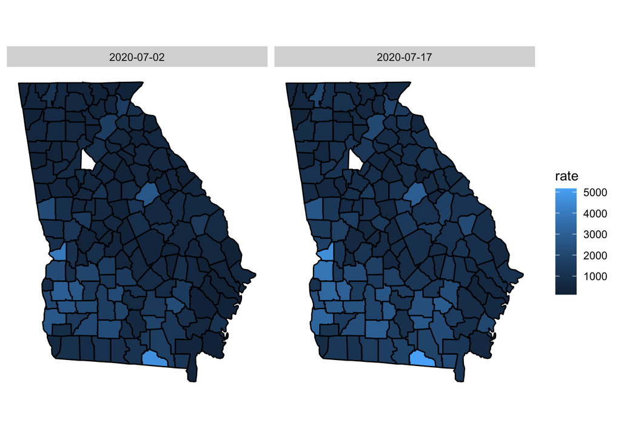

```r
georgia_map %>% ggplot(aes(x = long, y = lat, group = group, fill = rate)) +
                geom_polygon(color = "black") +
                theme(panel.grid.major = element_blank(),
                      panel.background = element_blank(),
                      axis.title = element_blank(),
                      axis.text = element_blank(),
                      axis.ticks = element_blank()) +
                coord_fixed(1.3) +
                facet_grid( ~ date)
```

One thing we notice is that one county is white - it’s missing rate data. On closer inspection of the `GeorgiaCounty` and `georgia_cases` data frames, we notice that DeKalb county is saved as “de kalb” in the `GeorgiaCounty` data frame, but as “DeKalb” in the in the `georgia_cases` data frame. That extra space means that even if we make all letters lowercase, `de kalb` and `dekalb` won’t match and when we join the data frames, DeKalb county will be missing rate data. We need to remove the space in the `GeorgiaCounty` data frame and then join the data frames again.

```r
GeorgiaCounty <- GeorgiaCounty %>%
  mutate(subregion = str_replace(subregion, " ", ""))

georgia_map <- data_full %>% mutate(county = str_to_lower(county)) %>%
  left_join(GeorgiaCounty, by = c("county" = "subregion"))

head(georgia_map)
```

```
## # A tibble: 6 × 13
##   date       county  state fips  cases deaths population  rate  long   lat group
##   <date>     <chr>   <chr> <chr> <dbl>  <dbl>      <dbl> <dbl> <dbl> <dbl> <dbl>
## 1 2020-07-02 appling Geor… 13001   266     14      18561 1433. -82.4  31.9     1
## 2 2020-07-02 appling Geor… 13001   266     14      18561 1433. -82.4  31.9     1
## 3 2020-07-02 appling Geor… 13001   266     14      18561 1433. -82.4  31.9     1
## 4 2020-07-02 appling Geor… 13001   266     14      18561 1433. -82.4  31.9     1
## 5 2020-07-02 appling Geor… 13001   266     14      18561 1433. -82.4  31.9     1
## 6 2020-07-02 appling Geor… 13001   266     14      18561 1433. -82.4  31.9     1
## # ℹ 2 more variables: order <int>, region <chr>
```

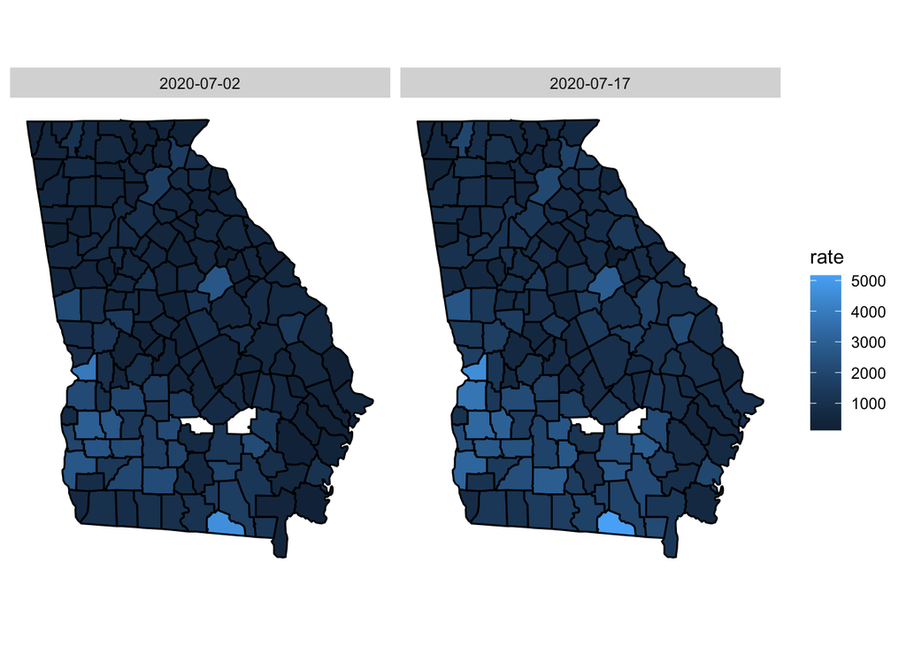

```r
georgia_map %>% ggplot(aes(x = long, y = lat, group = group, fill = rate)) +
                geom_polygon(color = "black") +
                theme(panel.grid.major = element_blank(),
                      panel.background = element_blank(),
                      axis.title = element_blank(),
                      axis.text = element_blank(),
                      axis.ticks = element_blank()) +
                coord_fixed(1.3) +
                facet_grid( ~ date)
```

Uh oh. It’s happened again but with 2 different counties. The names of the counties are not matching up again. Looking at a map of Georgia counties we can match the white counties to Ben Hill and Jeff Davis. Both of these had spaces in the `GeorgiaCounty` and `georgia_map` data (and thus matched), but we removed the spaces and now they don’t match. We have 2 options: remove all spaces in both data frames, or go back and only remove the space in DeKalb. Since we don’t need the names of the counties in this map, let’s remove all spaces from both data frames.

```r
data_full <- data_full %>%
  mutate(county = str_replace(county, " ", ""))

georgia_map <- data_full %>% mutate(county = str_to_lower(county)) %>%
  left_join(GeorgiaCounty, by = c("county" = "subregion"))
```

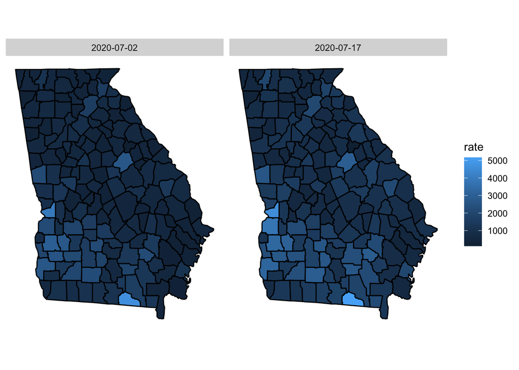

```r
georgia_map %>% ggplot(aes(x = long, y = lat, group = group, fill = rate)) +
                geom_polygon(color = "black") +
                theme(panel.grid.major = element_blank(),
                      panel.background = element_blank(),
                      axis.title = element_blank(),
                      axis.text = element_blank(),
                      axis.ticks = element_blank()) +
                coord_fixed(1.3) +
                facet_grid( ~ date)
```

This looks good and can see that there is a common legend for both plots - exactly what we want! Now we just need to change the colors a bit and customize the legend cutoff values, labels and title.

We’ll use the base R `cut` function to specify case rate ranges and create a new column in our `georgia_map` data frame named `manual_fill` to use in our plot. The first argument of the `cut` function specifies what variable or column you want to split into ranges. The cut points are then specified with the `breaks` argument, and the labels for the resulting intervals are specified with the `labels` argument. Finally, we need to add `right = TRUE` to indicate the intervals should be closed on the right and open on the left. This means, for example, an interval for 1-10 is represented as (1, 10] where 10 is included but 1 is not.

```r
georgia_map <- georgia_map %>%
  mutate(manual_fill = cut(rate, breaks = c(0, 620, 1070, 1622, 2960, Inf),
                           labels = c("1-620", "621-1,070", "1,071-1,622",
                                      "1,623-2,960", ">2,960"),
                           right = TRUE))
head(georgia_map)
```

```
## # A tibble: 6 × 14
##   date       county  state fips  cases deaths population  rate  long   lat group
##   <date>     <chr>   <chr> <chr> <dbl>  <dbl>      <dbl> <dbl> <dbl> <dbl> <dbl>
## 1 2020-07-02 appling Geor… 13001   266     14      18561 1433. -82.4  31.9     1
## 2 2020-07-02 appling Geor… 13001   266     14      18561 1433. -82.4  31.9     1
## 3 2020-07-02 appling Geor… 13001   266     14      18561 1433. -82.4  31.9     1
## 4 2020-07-02 appling Geor… 13001   266     14      18561 1433. -82.4  31.9     1
## 5 2020-07-02 appling Geor… 13001   266     14      18561 1433. -82.4  31.9     1
## 6 2020-07-02 appling Geor… 13001   266     14      18561 1433. -82.4  31.9     1
## # ℹ 3 more variables: order <int>, region <chr>, manual_fill <fct>
```

One final step before plotting is specifying the colors we want. The colors chosen from [this resource](http://www.stat.columbia.edu/~tzheng/files/Rcolor.pdf) are as close as possible to the colors used in the original plots.

```r
# Specify desired colors
pal <- c("lightskyblue2", "steelblue2", "dodgerblue3", "dodgerblue4", "red")
```

Using `manual_fill` to fill the counties and a `scale_fill_manual` layer specifying the title and labels of the legend, we get the desired result and can now see that the cases have actually increased between July 2nd and July 17th.

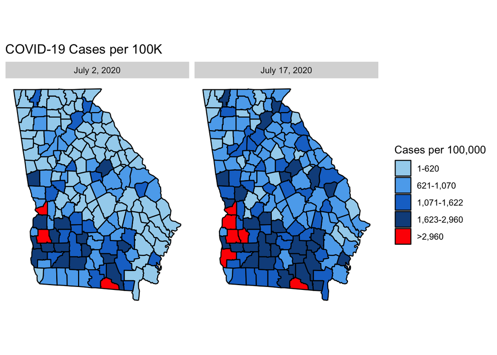

```r
date.labs <- c("July 2, 2020", "July 17, 2020")
names(date.labs) <- c("2020-07-02", "2020-07-17")

georgia_map %>% ggplot(aes(x = long, y = lat, group = group)) +
  geom_polygon(aes(fill = manual_fill), color = "black")  +
  scale_fill_manual(name = "Cases per 100,000", values = pal) +
  coord_fixed(1.3) +
  theme(panel.grid.major = element_blank(),
        panel.background = element_blank(),
        axis.title = element_blank(),
        axis.text = element_blank(),
        axis.ticks = element_blank()) +
  ggtitle("COVID-19 Cases per 100K") +
  facet_grid(. ~ date, labeller = labeller(date = date.labs))
```

And we can see the difference between our corrected version and the misleading original.

[figure not shown]

## Self-Assessment Questions

1. Create side-by-side maps showing fertility rates in 1960 and 2010 using the `gapminder` dataset. Use `facet_wrap` or `facet_grid` to display both years on consistent color scales. Some code is provided to make joining the data frames easier.

```r
library(tidyverse)
library(maps)
library(dslabs)
data(gapminder)

# Get gapminder data for 1960 and 2010
gap_filtered <- gapminder %>%
  filter(year %in% c(1960, 2010)) %>%
    mutate(country =
           revalue(country, c("Antigua and Barbuda" = "Antigua",
                              "Samoa" = "American Samoa",
                              "Congo, Rep." = "Republic of Congo",
                              "Congo, Dem. Rep." = "Democratic Republic of the Congo",
                              "Kyrgyz Republic" = "Kyrgyzstan",
                              "St. Lucia" = "Saint Lucia",
                              "St. Vincent and the Grenadines" = "Saint Vincent",
                              "Trinidad and Tobago" = "Trinidad",
                              "United Kingdom" = "UK",
                              "United States" = "USA")))

# Your code here
```

2. We did this above, but plot again the gun murder rates by US state using the `murders` dataset. This time, use a different color palette and the `sqrt` transformation for the legend.

```r
# Your code here
```

```r
# Your code here
```

## Self-Assessment Solutions

1. Create side-by-side maps showing fertility rates in 1960 and 2010 using the `gapminder` dataset. Use `facet_wrap` or `facet_grid` to display both years on consistent color scales. Some code is provided to make joining the data frames easier.

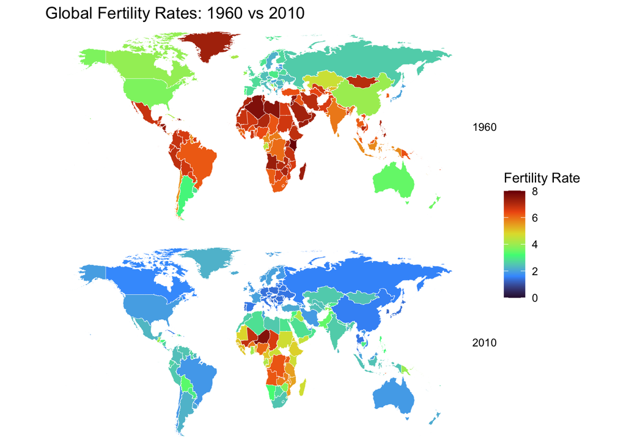

```r
library(tidyverse)
library(maps)
library(dslabs)
library(plyr)
data(gapminder)

# Get gapminder data for 1960 and 2010
gap_filtered <- gapminder %>%
  filter(year %in% c(1960, 2010)) %>%
    mutate(country =
           revalue(country, c("Antigua and Barbuda" = "Antigua",
                              "Samoa" = "American Samoa",
                              "Congo, Rep." = "Republic of Congo",
                              "Congo, Dem. Rep." = "Democratic Republic of the Congo",
                              "Kyrgyz Republic" = "Kyrgyzstan",
                              "St. Lucia" = "Saint Lucia",
                              "St. Vincent and the Grenadines" = "Saint Vincent",
                              "Trinidad and Tobago" = "Trinidad",
                              "United Kingdom" = "UK",
                              "United States" = "USA")))

# Get world map
world_map <- map_data("world") %>%
  dplyr::rename(country = region)

world_map %>%
  left_join(gap_filtered, by = c("country")) %>%
  filter(!is.na(fertility)) %>%
  ggplot(aes(long, lat, group = group, fill = fertility)) +
  geom_polygon(color = "white", size = 0.1) +
  scale_fill_viridis_c(option = "turbo", limits = c(0, 8), na.value = "grey90") +
  coord_fixed(1.3) +
  facet_grid(as.factor(year)~.) +
  labs(title = "Global Fertility Rates: 1960 vs 2010",
       fill = "Fertility Rate") +
  theme_void()
```

2. We did this above, but plot again the gun murder rates by US state using the `murders` dataset. This time, use a different color palette and the `sqrt` transformation for the legend.

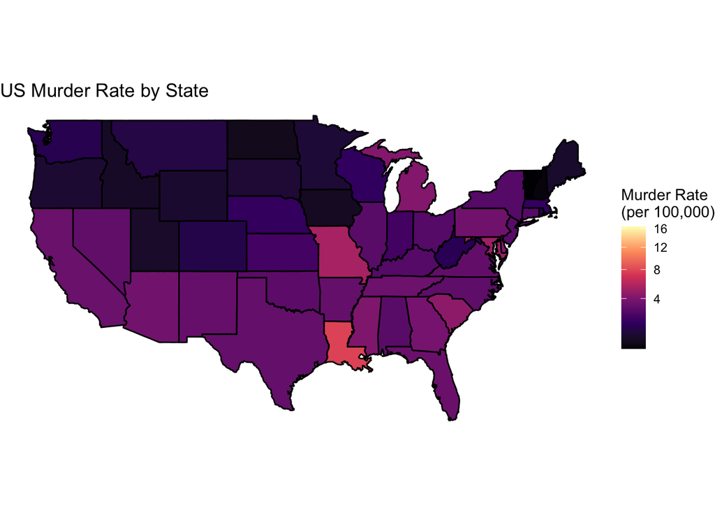

```r
library(tidyverse)
library(maps)
library(dslabs)
library(RColorBrewer)

data(murders)

murders <- murders %>%
  mutate(rate = total / population * 100000,
         region = tolower(state))

states_map <- map_data("state")

merged_data <- left_join(states_map, murders, by = "region")

merged_data %>%
ggplot(aes(long, lat, group = group, fill = rate)) +
  geom_polygon(color = "black") +
  scale_fill_viridis_c(option = "magma", trans = "sqrt") +
  theme_void() +
  labs(title = "US Murder Rate by State",
       fill = "Murder Rate \n(per 100,000)") +
  coord_fixed(1.3)
```

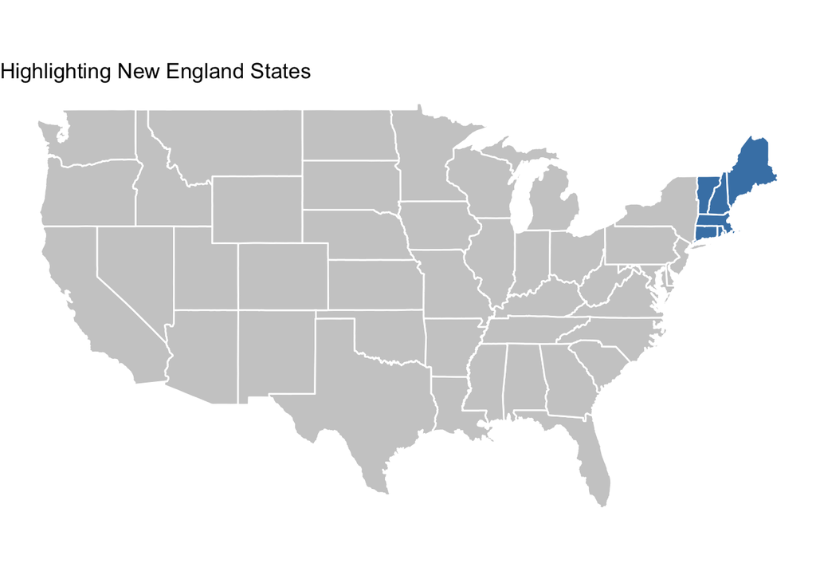

```r
ne_states <- c("maine", "vermont", "new hampshire",
               "massachusetts", "connecticut", "rhode island")

merged_data %>%
  mutate(ne = region %in% ne_states) %>%
  ggplot(aes(long, lat, group = group, fill = ne)) +
  geom_polygon(color = "white") +
  scale_fill_manual(values = c("grey80", "steelblue")) +
  coord_fixed(1.3) +
  labs(title = "Highlighting New England States") +
  theme_void() +
  guides(fill = "none")
```

Notes on why the colors work the way they do:

In the code, `fill = ne` means the fill color of each state depends on the variable `ne`, which is a logical variable (TRUE or FALSE) indicating whether the state is in New England or not. So:

- `ne` == `TRUE` → New England states
- `ne` == `FALSE` → all other states

you’re telling ggplot:

“Use `grey80` for one group (non–New England states) and `steelblue` for the other group (New England states).”

Because `ne` is logical (`FALSE`/`TRUE`), ggplot automatically matches (alphabetically): * FALSE → first color in the vector (`grey80`) * TRUE → second color (`steelblue`)